# Bayesian regression or GLMs

The authors of this work are:

- Ion Bueno Ulacia, 100364530
- Daniel Martín Cruz, 100384121

## a) Description of the data set

The used dataset can be downloaded from Kaggle in the following link: https://www.kaggle.com/prathamtripathi/regression-with-neural-networking.

The goal is predicting the **strength of concrete** per kilo Newton using the following variables:

- **Cement**: amount of cement.
- **Blast Furnace Slag**: slag produced in blast furnace.
- **Fly Ash**: amount of ash produced.
- **Water**: amount of water required.
- **Super-plasticizer**: rigidity of cement after drying.
- **Coarse Aggregate**: the coarse nature of the cement particles.
- **Fine Aggregate**: fineness of the cement.
- **Age**: time before it needs repairing.

```r
cement <- read.csv("concrete_data.csv")
colnames(cement)[1] <- "cement"
colnames(cement)[2] <- "blast_furnace_slag"
colnames(cement)[3] <- "fly_ash"
colnames(cement)[4] <- "water"
colnames(cement)[5] <- "superplasticizer"
colnames(cement)[6] <- "coarse_aggregate"
colnames(cement)[7] <- "fine_aggregate"
colnames(cement)[8] <- "age"
colnames(cement)[9] <- "strength"
attach(cement)
```

The dataset is composed by **1030** samples, **8** quantitative continuous variables and the target, which is also quantitative continuous.

```r
dim(cement)
```

```
## [1] 1030    9
```

## b) Frequentist analysis

We can obtain a scatterplot matrix to visualize the data.

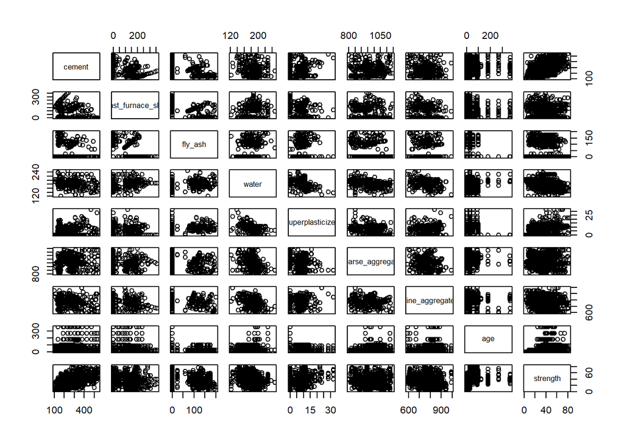

```r
pairs(cement)
```

At first instance, it does not seem that there is any strong correlation between the variables. For this reason, the multiple linear models uses all the available attributes to predict *strength*. We want to estimate the coefficients $\beta$ and the residual variance $\sigma^2$ maximizing the likelihood function $f(y|\beta, \sigma^2)$.

```r
freq_reg <- lm(strength ~ ., data = cement)
summary(freq_reg)
```

```
##
## Call:
## lm(formula = strength ~ ., data = cement)
##
## Residuals:
##     Min      1Q  Median      3Q     Max
## -28.654  -6.302   0.703   6.569  34.450
##
## Coefficients:
##                      Estimate Std. Error t value Pr(>|t|)
## (Intercept)        -23.331214  26.585504  -0.878 0.380372
## cement               0.119804   0.008489  14.113  < 2e-16 ***
## blast_furnace_slag   0.103866   0.010136  10.247  < 2e-16 ***
## fly_ash              0.087934   0.012583   6.988 5.02e-12 ***
## water               -0.149918   0.040177  -3.731 0.000201 ***
## superplasticizer     0.292225   0.093424   3.128 0.001810 **
## coarse_aggregate     0.018086   0.009392   1.926 0.054425 .
## fine_aggregate       0.020190   0.010702   1.887 0.059491 .
## age                  0.114222   0.005427  21.046  < 2e-16 ***
## ---
## Signif. codes:  0 '***' 0.001 '**' 0.01 '*' 0.05 '.' 0.1 ' ' 1
##
## Residual standard error: 10.4 on 1021 degrees of freedom
## Multiple R-squared:  0.6155, Adjusted R-squared:  0.6125
## F-statistic: 204.3 on 8 and 1021 DF,  p-value: < 2.2e-16
```

In addition to that, we can perform a test to see if the predictors are significantly different from zero.

```r
confint(freq_reg, level=.95)
```

```
##                            2.5 %      97.5 %
## (Intercept)        -7.549969e+01 28.83725959
## cement              1.031464e-01  0.13646225
## blast_furnace_slag  8.397642e-02  0.12375519
## fly_ash             6.324220e-02  0.11262644
## water              -2.287574e-01 -0.07107942
## superplasticizer    1.088994e-01  0.47554975
## coarse_aggregate   -3.440777e-04  0.03651651
## fine_aggregate     -8.094602e-04  0.04119016
## age                 1.035724e-01  0.12487171
```

As expected, only the intercept and the variables *coarse_aggregate* and *fine_aggregate* contain zero in the confidence interval. For this reason, we are going to perform a stepwise selection removing predictors with BIC as criteria in order to see if the performance can improve.

```r
freq_reg_filtered <- MASS::stepAIC(freq_reg, direction = "backward", k = log(nrow(cement)))
```

```
## Start:  AIC=4877.35
## strength ~ cement + blast_furnace_slag + fly_ash + water + superplasticizer +
##     coarse_aggregate + fine_aggregate + age
##
##                      Df Sum of Sq    RSS    AIC
## - fine_aggregate      1       385 110798 4874.0
## - coarse_aggregate    1       401 110814 4874.1
## <none>                            110413 4877.3
## - superplasticizer    1      1058 111471 4880.2
## - water               1      1506 111919 4884.4
## - fly_ash             1      5281 115694 4918.5
## - blast_furnace_slag  1     11356 121769 4971.2
## - cement              1     21539 131952 5054.0
## - age                 1     47902 158315 5241.6
##
## Step:  AIC=4873.99
## strength ~ cement + blast_furnace_slag + fly_ash + water + superplasticizer +
##     coarse_aggregate + age
##
##                      Df Sum of Sq    RSS    AIC
## - coarse_aggregate    1        45 110843 4867.5
## <none>                            110798 4874.0
## - superplasticizer    1       887 111685 4875.3
## - water               1      8504 119303 4943.2
## - fly_ash             1      8559 119357 4943.7
## - blast_furnace_slag  1     30689 141487 5118.9
## - age                 1     47518 158316 5234.6
## - cement              1     64017 174815 5336.8
##
## Step:  AIC=4867.48
## strength ~ cement + blast_furnace_slag + fly_ash + water + superplasticizer +
##     age
##
##                      Df Sum of Sq    RSS    AIC
## <none>                            110843 4867.5
## - superplasticizer    1       875 111718 4868.6
## - fly_ash             1      8537 119381 4937.0
## - water               1     11543 122386 4962.6
## - blast_furnace_slag  1     32750 143593 5127.2
## - age                 1     47728 158571 5229.4
## - cement              1     66774 177617 5346.2
```

```r
summary(freq_reg_filtered)
```

```
##
## Call:
## lm(formula = strength ~ cement + blast_furnace_slag + fly_ash +
##     water + superplasticizer + age, data = cement)
##
## Residuals:
##     Min      1Q  Median      3Q     Max
## -28.987  -6.469   0.653   6.547  34.732
##
## Coefficients:
##                     Estimate Std. Error t value Pr(>|t|)
## (Intercept)        28.992982   4.213202   6.881 1.03e-11 ***
## cement              0.105413   0.004246  24.825  < 2e-16 ***
## blast_furnace_slag  0.086472   0.004974  17.385  < 2e-16 ***
## fly_ash             0.068660   0.007735   8.877  < 2e-16 ***
## water              -0.218088   0.021129 -10.322  < 2e-16 ***
## superplasticizer    0.240311   0.084567   2.842  0.00458 **
## age                 0.113492   0.005407  20.988  < 2e-16 ***
## ---
## Signif. codes:  0 '***' 0.001 '**' 0.01 '*' 0.05 '.' 0.1 ' ' 1
##
## Residual standard error: 10.41 on 1023 degrees of freedom
## Multiple R-squared:  0.614,  Adjusted R-squared:  0.6118
## F-statistic: 271.2 on 6 and 1023 DF,  p-value: < 2.2e-16
```

Looking into the final results, we can see the predictors *coarse_aggregate* and *fine_aggregate* have been removed from the model getting a best score in terms of BIC. Mention how not using these variables causes that the intercept becomes significant.

In next cell the obtained BIC scores of both models are printed.

```r
extractAIC(freq_reg, k = log(nrow(cement)))[2]
```

```
## [1] 4877.346
```

```r
extractAIC(freq_reg_filtered, k = log(nrow(cement)))[2]
```

```
## [1] 4867.476
```

As commented, the model resulted from the stepwise process obtains a smaller BIC value, what means it overcomes the original model.

We can compare predicted with observed values.

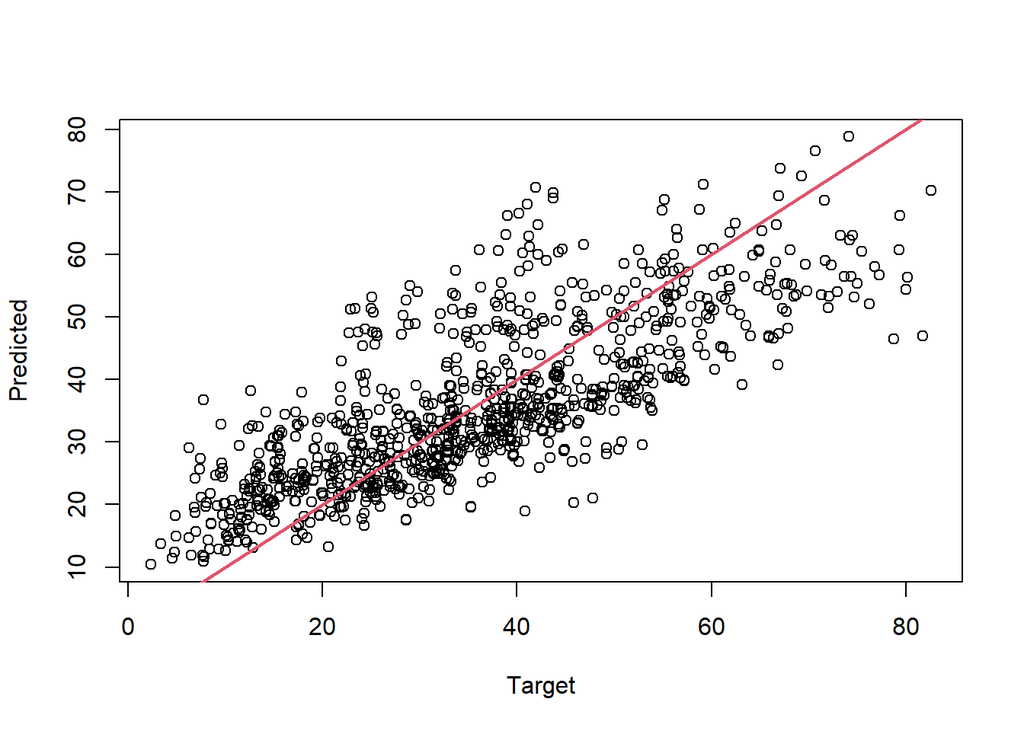

```r
plot(strength, predict(freq_reg_filtered), xlab = "Target", ylab = "Predicted")
abline(0, 1, col = 2, lwd = 2)
```

The straight red line represents the perfect result, in which the predicted value match with the target. As we can see, the points are close around it, so we could that say the model is performing well.

## c) Bayesian analysis

In a Bayesian analysis the data are fixed and the model parameters behave as random variables. It is employed the Bayes Theorem to inference on the parameters, which are the same as before, $\beta$ and $\sigma^2$. The posterior distribution is defined as:
$$f(\beta, \sigma^2 | y) \propto f(y|\beta, \sigma^2) f(\beta, \sigma^2)$$

We have to assume a prior distribution $f(y|\beta, \sigma^2)$. At first instance we are going to use a **non-informative** prior distribution and then we tried a **informative** one.

### Non-informative prior distribution

We are going to use the *MCMCglmm* R package, which has as default a normal prior for the $\beta$ coefficients:
$$\beta \sim N(m, V)$$
with $m=0$ and $V = 10^{10} I$. The variance follows an inverse gamma distribution:
$$\sigma^2 \sim IG(\frac{a}{2}, \frac{b}{2})$$

```r
library(MCMCglmm)
```

With this method we implement a Markov Chain Monte Carlo (MCMC) algorithm to obtain samples from the posterior distribution.

```r
bayes_reg_no_inf <- MCMCglmm(strength ~
                               cement +
                               blast_furnace_slag +
                               fly_ash +
                               water +
                               superplasticizer +
                               coarse_aggregate +
                               fine_aggregate +
                               age,
                             data = cement, verbose = FALSE)
summary(bayes_reg_no_inf)
```

```
##
##  Iterations = 3001:12991
##  Thinning interval  = 10
##  Sample size  = 1000
##
##  DIC: 7757.992
##
##  R-structure:  ~units
##
##       post.mean l-95% CI u-95% CI eff.samp
## units     108.3     98.5    117.7     1000
##
##  Location effects: strength ~ cement + blast_furnace_slag + fly_ash + water + superplasticizer + coarse_aggregate + fine_aggregate + age
##
##                     post.mean   l-95% CI   u-95% CI eff.samp  pMCMC
## (Intercept)        -2.320e+01 -7.667e+01  2.729e+01   1000.0  0.386
## cement              1.196e-01  1.026e-01  1.360e-01   1000.0 <0.001 ***
## blast_furnace_slag  1.038e-01  8.272e-02  1.226e-01   1000.0 <0.001 ***
## fly_ash             8.771e-02  6.201e-02  1.119e-01    845.5 <0.001 ***
## water              -1.491e-01 -2.288e-01 -7.168e-02   1000.0 <0.001 ***
## superplasticizer    2.947e-01  1.206e-01  4.727e-01   1000.0  0.004 **
## coarse_aggregate    1.802e-02 -2.381e-04  3.560e-02   1000.0  0.066 .
## fine_aggregate      1.994e-02 -1.762e-03  4.047e-02   1000.0  0.072 .
## age                 1.141e-01  1.045e-01  1.254e-01   1000.0 <0.001 ***
## ---
## Signif. codes:  0 '***' 0.001 '**' 0.01 '*' 0.05 '.' 0.1 ' ' 1
```

At first instance we can see how the influence of the predictors in the response are very similar respect to the multiple linear regression. For this reason we removed the same variables than before, *coarse_aggregate* and *fine_aggregate*. This process will be better explained and discussed in section d).

```r
bayes_reg_no_inf_filtered <- MCMCglmm(strength ~
                               cement +
                               blast_furnace_slag +
                               fly_ash +
                               water +
                               superplasticizer +
                               age,
                             data = cement, verbose = FALSE)
summary(bayes_reg_no_inf_filtered)
```

```
##
##  Iterations = 3001:12991
##  Thinning interval  = 10
##  Sample size  = 1000
##
##  DIC: 7757.937
##
##  R-structure:  ~units
##
##       post.mean l-95% CI u-95% CI eff.samp
## units     108.2    99.32    118.1     1000
##
##  Location effects: strength ~ cement + blast_furnace_slag + fly_ash + water + superplasticizer + age
##
##                    post.mean l-95% CI u-95% CI eff.samp  pMCMC
## (Intercept)         29.11978 21.27297 36.79161     1143 <0.001 ***
## cement               0.10543  0.09664  0.11362     1000 <0.001 ***
## blast_furnace_slag   0.08659  0.07731  0.09716     1000 <0.001 ***
## fly_ash              0.06910  0.05350  0.08313     1131 <0.001 ***
## water               -0.21882 -0.25864 -0.18079     1210 <0.001 ***
## superplasticizer     0.23782  0.07292  0.39269     1000  0.004 **
## age                  0.11333  0.10327  0.12345     1000 <0.001 ***
## ---
## Signif. codes:  0 '***' 0.001 '**' 0.01 '*' 0.05 '.' 0.1 ' ' 1
```

```r
c(bayes_reg_no_inf$DIC, bayes_reg_no_inf_filtered$DIC)
```

```
## [1] 7757.992 7757.937
```

After several executions, we have seen that the DIC can improve or not, the difference with the previous model is minimum. Mention the results are not always the same due to the randomization introduced by the Markov Chain Monte Carlo sampling.

The $\beta$ parameters can be obtained using the posterior mean, which are the expected value the posterior distribution.

```r
beta_bayes_no_inf <- bayes_reg_no_inf_filtered$Sol
beta_reg <- freq_reg_filtered$coefficients
colMeans(beta_bayes_no_inf)
```

```
##        (Intercept)             cement blast_furnace_slag            fly_ash
##        29.11978177         0.10543410         0.08659060         0.06910099
##              water   superplasticizer                age
##        -0.21881756         0.23781645         0.11333482
```

```r
beta_reg
```

```
##        (Intercept)             cement blast_furnace_slag            fly_ash
##        28.99298223         0.10541342         0.08647157         0.06866036
##              water   superplasticizer                age
##        -0.21808827         0.24031084         0.11349188
```

As we can see, the parameters are very close.

In a Bayesian model, the Highest Posterior Density (HPD) intervals are the shortest interval of given probability for the posterior distribution. In next cell the confidence intervals of both models are shown:

```r
HPDinterval(beta_bayes_no_inf, level = .95)
```

```
##                          lower       upper
## (Intercept)        21.27297128 36.79161430
## cement              0.09663523  0.11361934
## blast_furnace_slag  0.07731325  0.09716350
## fly_ash             0.05349880  0.08313494
## water              -0.25864028 -0.18078893
## superplasticizer    0.07291876  0.39268833
## age                 0.10326664  0.12344946
## attr(,"Probability")
## [1] 0.95
```

```r
confint(freq_reg_filtered, level = .95)
```

```
##                          2.5 %      97.5 %
## (Intercept)        20.72547684 37.26048762
## cement              0.09708097  0.11374586
## blast_furnace_slag  0.07671157  0.09623157
## fly_ash             0.05348205  0.08383867
## water              -0.25955032 -0.17662622
## superplasticizer    0.07436661  0.40625507
## age                 0.10288088  0.12410289
```

As before, the results are almost the same. Last point to check is the estimated $\sigma^2$.

```r
colMeans(bayes_reg_no_inf_filtered$VCV)
```

```
##    units
## 108.2217
```

```r
mean(freq_reg_filtered$residuals^2)
```

```
## [1] 107.6148
```

The posterior mean of $\sigma^2$ is close to the classical mean squared residuals.

We can also compare the prediction intervals of both models.

```r
predict(bayes_reg_no_inf_filtered, interval="prediction")[1:5, ]
```

```
##        fit      lwr      upr
## 1 54.68360 35.07792 76.15338
## 2 54.27594 33.60173 74.49151
## 3 57.76632 39.14427 79.76457
## 4 68.32063 47.76642 88.68460
## 5 60.58743 39.47646 80.58204
```

```r
predict(freq_reg_filtered, interval="prediction")[1:5, ]
```

```
##        fit      lwr      upr
## 1 54.36448 33.82505 74.90391
## 2 54.36448 33.82505 74.90391
## 3 57.28382 36.69413 77.87352
## 4 68.06555 47.35498 88.77613
## 5 60.36105 39.64160 81.08050
```

Which are also almost equal. If we plot the points it can be seen how the differences in the predictions are minimum.

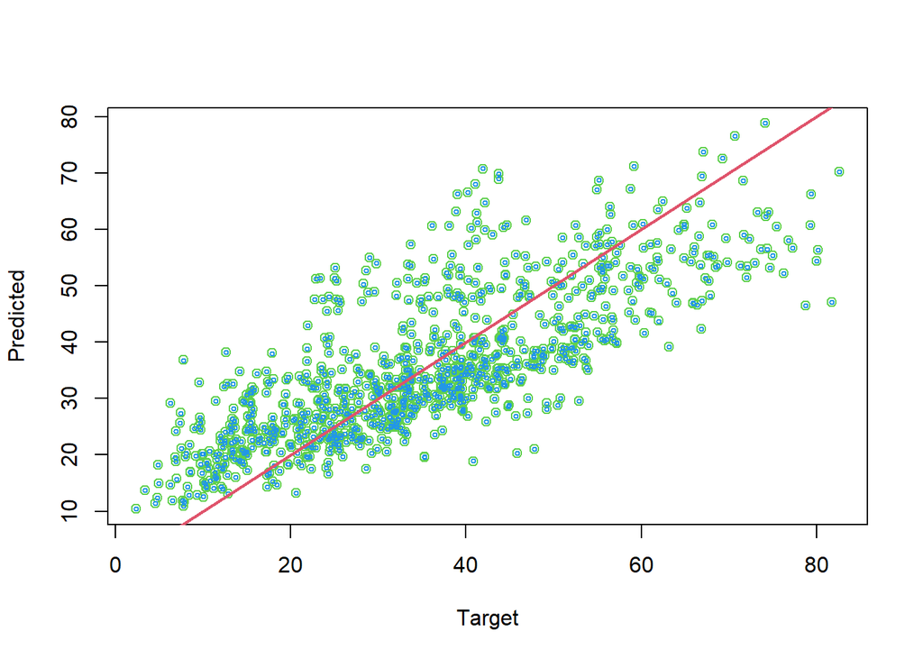

```r
plot(strength, predict(bayes_reg_no_inf_filtered), xlab = "Target", ylab = "Predicted", col = 3, cex = 1)
points(strength, predict(freq_reg_filtered), col = 4, cex = 0.5)
abline(0, 1, col = 2, lwd = 2)
```

### Informative prior distribution

We can introduce a more informative prior on the $\beta$ coefficients constraining their magnitude a priori.
$$\beta \sim N(0, \frac{1}{\lambda}I)$$

We selected $\lambda=0.05$.

```r
p <- ncol(cement) - 1
lambda <- 0.05
prior <- list(B=list(mu=rep(0,p+1),V=diag(1/lambda,p+1)))
bayes_reg_inf <- MCMCglmm(strength ~
                               cement +
                               blast_furnace_slag +
                               fly_ash +
                               water +
                               superplasticizer +
                               coarse_aggregate +
                               fine_aggregate +
                               age,
                          data = cement, prior = prior, verbose = FALSE)
summary(bayes_reg_inf)
```

```
##
##  Iterations = 3001:12991
##  Thinning interval  = 10
##  Sample size  = 1000
##
##  DIC: 7756.821
##
##  R-structure:  ~units
##
##       post.mean l-95% CI u-95% CI eff.samp
## units     108.5     98.7    117.9     1000
##
##  Location effects: strength ~ cement + blast_furnace_slag + fly_ash + water + superplasticizer + coarse_aggregate + fine_aggregate + age
##
##                    post.mean  l-95% CI  u-95% CI eff.samp  pMCMC
## (Intercept)        -0.716747 -8.816322  7.879451    867.8  0.860
## cement              0.113450  0.104734  0.122247   1000.0 <0.001 ***
## blast_furnace_slag  0.096463  0.085852  0.107792    862.0 <0.001 ***
## fly_ash             0.079603  0.065671  0.098289   1000.0 <0.001 ***
## water              -0.181728 -0.214586 -0.147663   1000.0 <0.001 ***
## superplasticizer    0.263543  0.083075  0.431194    944.9  0.006 **
## coarse_aggregate    0.010640  0.003805  0.017709   1000.0  0.002 **
## fine_aggregate      0.011617  0.003602  0.019308   1000.0  0.002 **
## age                 0.114210  0.104389  0.126910   1000.0 <0.001 ***
## ---
## Signif. codes:  0 '***' 0.001 '**' 0.01 '*' 0.05 '.' 0.1 ' ' 1
```

If we compare the obtained DIC for models using non-informative and informative prior distributions.

```r
c(bayes_reg_no_inf_filtered$DIC, bayes_reg_inf$DIC)
```

```
## [1] 7757.937 7756.821
```

The option introducing prior information obtains a better score.

As before, we can compare the results respect the frequentist ones. The used variables are different, so it does not make a lot of sense looking into the estimated $\beta$ coefficients or the confidence intervals of these ones.

However, we can still check the estimated residual variance $\sigma^2$.

```r
colMeans(bayes_reg_inf$VCV)
```

```
##    units
## 108.4896
```

```r
mean(freq_reg_filtered$residuals^2)
```

```
## [1] 107.6148
```

As before, the values are very close.

Looking into the prediction intervals of the first five points.

```r
predict(bayes_reg_inf, interval="prediction")[1:5, ]
```

```
##        fit      lwr      upr
## 1 54.04362 33.53293 74.42531
## 2 53.57011 35.04889 75.83031
## 3 56.67506 36.52623 76.86137
## 4 67.74728 49.42793 90.14717
## 5 60.51147 40.16773 81.65996
```

```r
predict(freq_reg_filtered, interval="prediction")[1:5, ]
```

```
##        fit      lwr      upr
## 1 54.36448 33.82505 74.90391
## 2 54.36448 33.82505 74.90391
## 3 57.28382 36.69413 77.87352
## 4 68.06555 47.35498 88.77613
## 5 60.36105 39.64160 81.08050
```

The obtained results are almost identical. We can plot the predicted points by the multiple linear regression and the bayesian regression model.

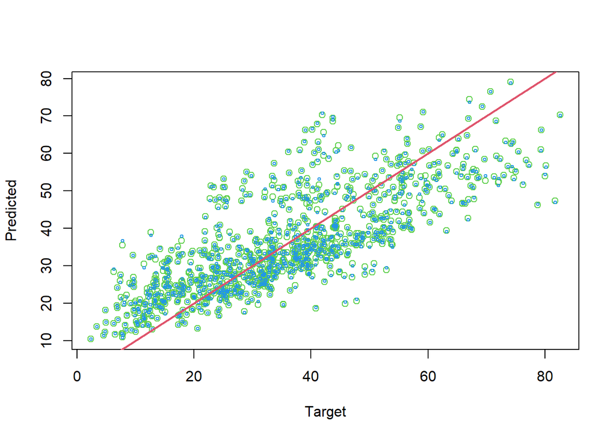

```r
plot(strength, predict(bayes_reg_inf), xlab = "Target", ylab = "Predicted", col = 3, cex = 1)
points(strength, predict(freq_reg_filtered), col = 4, cex = 0.5)
abline(0, 1, col = 2, lwd = 2)
```

As expected, the predictions are almost the same. Nevertheless, to mention that more differences can be appreciated using prior information, the points do not match so well as in the previous case.

## d) Variable selection

The decision to use or not a certain variable in the model can be carried out using DIC as criteria. It is defined as:
$$\text{DIC} = \bar{D} + 2p_D$$

The $\bar{D}$ is the posterior mean deviance, which means how far the model is for a perfect fit (overfitted). The parameter $p_D$ is the effective number of parameters in the Bayesian context. If the number of parameters in a model increases, $\bar{D}$ is going to decrease, so $p_D$ term compensates this effect by favoring models with a smaller number of parameters. Lower values of the DIC indicate that the model is fitting well the problem.

We have already explained a variable selection process using DIC in the non-informative model. When removing the attributes *coarse_aggregate* and *fine_aggregate*, the value is reduced.

```r
c(bayes_reg_no_inf$DIC, bayes_reg_no_inf_filtered$DIC)
```

```
## [1] 7757.992 7757.937
```

This selection is motivated by the significance of the predictors into the response. Same process is going to be carried in the informative model, in order to see if we can obtain a better performance.

```r
summary(bayes_reg_inf)
```

```
##
##  Iterations = 3001:12991
##  Thinning interval  = 10
##  Sample size  = 1000
##
##  DIC: 7756.821
##
##  R-structure:  ~units
##
##       post.mean l-95% CI u-95% CI eff.samp
## units     108.5     98.7    117.9     1000
##
##  Location effects: strength ~ cement + blast_furnace_slag + fly_ash + water + superplasticizer + coarse_aggregate + fine_aggregate + age
##
##                    post.mean  l-95% CI  u-95% CI eff.samp  pMCMC
## (Intercept)        -0.716747 -8.816322  7.879451    867.8  0.860
## cement              0.113450  0.104734  0.122247   1000.0 <0.001 ***
## blast_furnace_slag  0.096463  0.085852  0.107792    862.0 <0.001 ***
## fly_ash             0.079603  0.065671  0.098289   1000.0 <0.001 ***
## water              -0.181728 -0.214586 -0.147663   1000.0 <0.001 ***
## superplasticizer    0.263543  0.083075  0.431194    944.9  0.006 **
## coarse_aggregate    0.010640  0.003805  0.017709   1000.0  0.002 **
## fine_aggregate      0.011617  0.003602  0.019308   1000.0  0.002 **
## age                 0.114210  0.104389  0.126910   1000.0 <0.001 ***
## ---
## Signif. codes:  0 '***' 0.001 '**' 0.01 '*' 0.05 '.' 0.1 ' ' 1
```

In this case *coarse_aggregate* and *fine_aggregate* are more relevant than in the non-informative model. However, the intercept remains being non significant, so we are going to remove it.

```r
p <- ncol(cement) - 2
lambda <- 0.05
prior <- list(B=list(mu=rep(0,p+1),V=diag(1/lambda,p+1)))
bayes_reg_inf_filtered <- MCMCglmm(strength ~ -1 +
                               cement +
                               blast_furnace_slag +
                               fly_ash +
                               water +
                               superplasticizer +
                               coarse_aggregate +
                               fine_aggregate +
                               age,
                          data = cement, prior = prior, verbose = FALSE)
summary(bayes_reg_inf_filtered)
```

```
##
##  Iterations = 3001:12991
##  Thinning interval  = 10
##  Sample size  = 1000
##
##  DIC: 7756.827
##
##  R-structure:  ~units
##
##       post.mean l-95% CI u-95% CI eff.samp
## units     108.2    98.39    116.9     1000
##
##  Location effects: strength ~ -1 + cement + blast_furnace_slag + fly_ash + water + superplasticizer + coarse_aggregate + fine_aggregate + age
##
##                    post.mean  l-95% CI  u-95% CI eff.samp  pMCMC
## cement              0.113428  0.104702  0.121297     1000 <0.001 ***
## blast_furnace_slag  0.096282  0.086526  0.106849     1196 <0.001 ***
## fly_ash             0.079232  0.062965  0.094432     1231 <0.001 ***
## water              -0.182407 -0.218345 -0.154901     1000 <0.001 ***
## superplasticizer    0.265390  0.099717  0.439925     1000  0.004 **
## coarse_aggregate    0.010141  0.004326  0.015888     1000 <0.001 ***
## fine_aggregate      0.011501  0.004385  0.018238     1000  0.002 **
## age                 0.114086  0.103143  0.124201     1016 <0.001 ***
## ---
## Signif. codes:  0 '***' 0.001 '**' 0.01 '*' 0.05 '.' 0.1 ' ' 1
```

As with the case of non-informative prior distribution, the DIC can improve or not in each execution due to the randomization introduced by the Markov Chain Monte Carlo sampling. The difference is minimum respect the two models.

```r
c(bayes_reg_inf$DIC, bayes_reg_inf_filtered$DIC)
```

```
## [1] 7756.821 7756.827
```

We can continue removing other attributes, for example *fine_aggregate* which is one of the less significant.

```r
p <- ncol(cement) - 3
lambda <- 0.05
prior <- list(B=list(mu=rep(0,p+1),V=diag(1/lambda,p+1)))
bayes_reg_inf_filtered2 <- MCMCglmm(strength ~ -1 +
                               cement +
                               blast_furnace_slag +
                               fly_ash +
                               water +
                               superplasticizer +
                               coarse_aggregate +
                               age,
                          data = cement, prior = prior, verbose = FALSE)
bayes_reg_inf_filtered2$DIC
```

```
## [1] 7764.94
```

But the result is worse. If we keep the intercept and remove this variable.

```r
p <- ncol(cement) - 2
lambda <- 0.05
prior <- list(B=list(mu=rep(0,p+1),V=diag(1/lambda,p+1)))
bayes_reg_inf_filtered3 <- MCMCglmm(strength ~
                               cement +
                               blast_furnace_slag +
                               fly_ash +
                               water +
                               superplasticizer +
                               coarse_aggregate +
                               age,
                          data = cement, prior = prior, verbose = FALSE)
bayes_reg_inf_filtered3$DIC
```

```
## [1] 7762.711
```

The results improves but it is still worse than the previous one in which we only removed the intercept.

```r
c(bayes_reg_no_inf$DIC, bayes_reg_no_inf_filtered$DIC,
  bayes_reg_inf$DIC, bayes_reg_inf_filtered$DIC,
  bayes_reg_inf_filtered2$DIC, bayes_reg_inf_filtered3$DIC)
```

```
## [1] 7757.992 7757.937 7756.821 7756.827 7764.940 7762.711
```

As we have commented, the best model in terms of DIC criteria is the one with informative prior distribution and using all the available predictors. Excluding the intercept results in a minimum difference respect the DIC.

## e) Conclusions

The Bayesian approach in this problem has successfully obtained the same results than the multiple linear regression. Introducing prior information distributions has resulted in a better performance. This lead us to think that knowing more about the data and how it may be distributed has a direct effect in how well our model is going to behave.

In addition to that, the DIC criteria allowed us to perform a selection between models taking into account how well they fit and avoiding the overfitting which may be caused by using a lot of parameters. Mention how the significance of the variables have been different in the three approaches: frequentist analysis and using non-informative and informative prior distributions in the bayesian analysis. For this reason, the variable selection should be carried out individually and evaluating the DIC each time a predictors is added or removed, since the significance of the rest change, as we have seen.

Finally, it is also important to consider the randomization introduced by the Markov Chain Monte Carlo sampling in each execution when we want to compare models’ performance. We can fix the seed in order to get deterministic results.